% R Graphics  
% Weicheng Zhu  
% 2012/06/06

## Highly recommend you to use Chrome to read this tutorial! This tutorial is mainly for Windows users.

# Outline

## Examples

Now we are going to one of the most attractive part of R language: **Graphics**.  
First, before we actually go into it, let's enjoy the view of R graphics together :)  
The purpose here is just to make you have an overall impression of the range of graphical images that can produced by R :)

```
##
##
##  demo(graphics)
##  ---- ~~~~~~~~
##
## > require(datasets)
##
## > require(grDevices); require(graphics)
##
## > ## Here is some code which illustrates some of the differences between
## > ## R and S graphics capabilities.  Note that colors are generally specified
## > ## by a character string name (taken from the X11 rgb.txt file) and that line
## > ## textures are given similarly.  The parameter "bg" sets the background
## > ## parameter for the plot and there is also an "fg" parameter which sets
## > ## the foreground color.
## >
## >
## > x <- stats::rnorm(50)
##
## > opar <- par(bg = "white")
##
## > plot(x, ann = FALSE, type = "n")
```

```
##
## > abline(h = 0, col = gray(.90))
##
## > lines(x, col = "green4", lty = "dotted")
##
## > points(x, bg = "limegreen", pch = 21)
##
## > title(main = "Simple Use of Color In a Plot",
## +       xlab = "Just a Whisper of a Label",
## +       col.main = "blue", col.lab = gray(.8),
## +       cex.main = 1.2, cex.lab = 1.0, font.main = 4, font.lab = 3)
##
## > ## A little color wheel.    This code just plots equally spaced hues in
## > ## a pie chart.    If you have a cheap SVGA monitor (like me) you will
## > ## probably find that numerically equispaced does not mean visually
## > ## equispaced.  On my display at home, these colors tend to cluster at
## > ## the RGB primaries.  On the other hand on the SGI Indy at work the
## > ## effect is near perfect.
## >
## > par(bg = "gray")
##
## > pie(rep(1,24), col = rainbow(24), radius = 0.9)
```

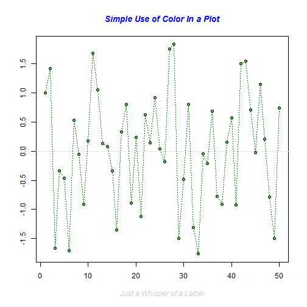

```
##
## > title(main = "A Sample Color Wheel", cex.main = 1.4, font.main = 3)
##
## > title(xlab = "(Use this as a test of monitor linearity)",
## +       cex.lab = 0.8, font.lab = 3)
##
## > ## We have already confessed to having these.  This is just showing off X11
## > ## color names (and the example (from the postscript manual) is pretty "cute".
## >
## > pie.sales <- c(0.12, 0.3, 0.26, 0.16, 0.04, 0.12)
##
## > names(pie.sales) <- c("Blueberry", "Cherry",
## +              "Apple", "Boston Cream", "Other", "Vanilla Cream")
##
## > pie(pie.sales,
## +     col = c("purple","violetred1","green3","cornsilk","cyan","white"))
```

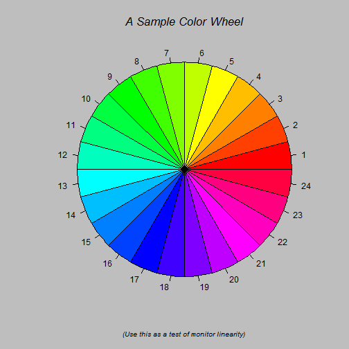

```
##
## > title(main = "January Pie Sales", cex.main = 1.8, font.main = 1)
##
## > title(xlab = "(Don't try this at home kids)", cex.lab = 0.8, font.lab = 3)
##
## > ## Boxplots:  I couldn't resist the capability for filling the "box".
## > ## The use of color seems like a useful addition, it focuses attention
## > ## on the central bulk of the data.
## >
## > par(bg="cornsilk")
##
## > n <- 10
##
## > g <- gl(n, 100, n*100)
##
## > x <- rnorm(n*100) + sqrt(as.numeric(g))
##
## > boxplot(split(x,g), col="lavender", notch=TRUE)
```

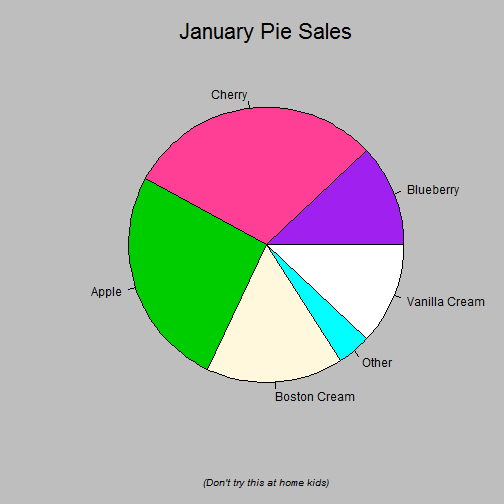

```
##
## > title(main="Notched Boxplots", xlab="Group", font.main=4, font.lab=1)
##
## > ## An example showing how to fill between curves.
## >
## > par(bg="white")
##
## > n <- 100
##
## > x <- c(0,cumsum(rnorm(n)))
##
## > y <- c(0,cumsum(rnorm(n)))
##
## > xx <- c(0:n, n:0)
##
## > yy <- c(x, rev(y))
##
## > plot(xx, yy, type="n", xlab="Time", ylab="Distance")
```

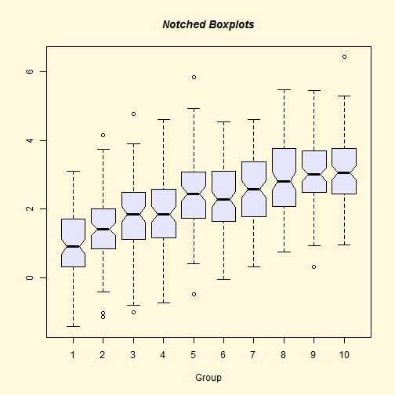

```
##
## > polygon(xx, yy, col="gray")
##
## > title("Distance Between Brownian Motions")
##
## > ## Colored plot margins, axis labels and titles.    You do need to be
## > ## careful with these kinds of effects.    It's easy to go completely
## > ## over the top and you can end up with your lunch all over the keyboard.
## > ## On the other hand, my market research clients love it.
## >
## > x <- c(0.00, 0.40, 0.86, 0.85, 0.69, 0.48, 0.54, 1.09, 1.11, 1.73, 2.05, 2.02)
##
## > par(bg="lightgray")
##
## > plot(x, type="n", axes=FALSE, ann=FALSE)
```

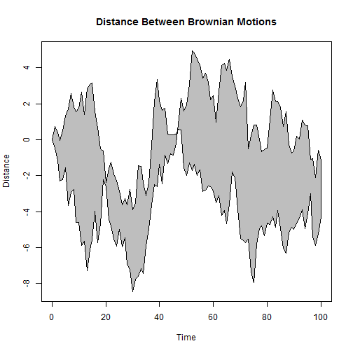

```
##
## > usr <- par("usr")
##
## > rect(usr[1], usr[3], usr[2], usr[4], col="cornsilk", border="black")
##
## > lines(x, col="blue")
##
## > points(x, pch=21, bg="lightcyan", cex=1.25)
##
## > axis(2, col.axis="blue", las=1)
##
## > axis(1, at=1:12, lab=month.abb, col.axis="blue")
##
## > box()
##
## > title(main= "The Level of Interest in R", font.main=4, col.main="red")
##
## > title(xlab= "1996", col.lab="red")
##
## > ## A filled histogram, showing how to change the font used for the
## > ## main title without changing the other annotation.
## >
## > par(bg="cornsilk")
##
## > x <- rnorm(1000)
##
## > hist(x, xlim=range(-4, 4, x), col="lavender", main="")
```

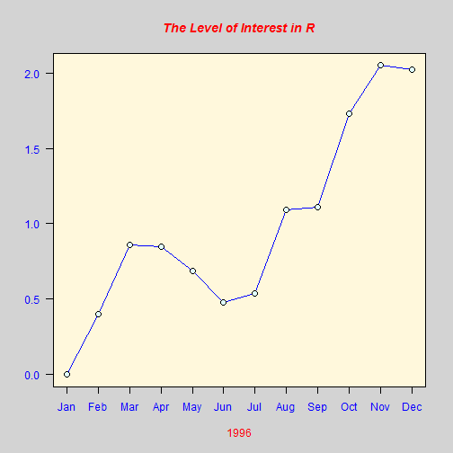

```
##
## > title(main="1000 Normal Random Variates", font.main=3)
##
## > ## A scatterplot matrix
## > ## The good old Iris data (yet again)
## >
## > pairs(iris[1:4], main="Edgar Anderson's Iris Data", font.main=4, pch=19)
```

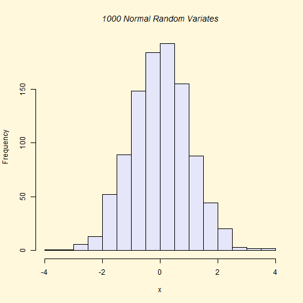

```
##
## > pairs(iris[1:4], main="Edgar Anderson's Iris Data", pch=21,
## +       bg = c("red", "green3", "blue")[unclass(iris$Species)])
```

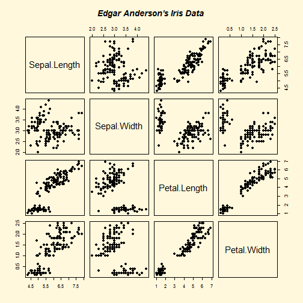

```
##
## > ## Contour plotting
## > ## This produces a topographic map of one of Auckland's many volcanic "peaks".
## >
## > x <- 10*1:nrow(volcano)
##
## > y <- 10*1:ncol(volcano)
##
## > lev <- pretty(range(volcano), 10)
##
## > par(bg = "lightcyan")
##
## > pin <- par("pin")
##
## > xdelta <- diff(range(x))
##
## > ydelta <- diff(range(y))
##
## > xscale <- pin[1]/xdelta
##
## > yscale <- pin[2]/ydelta
##
## > scale <- min(xscale, yscale)
##
## > xadd <- 0.5*(pin[1]/scale - xdelta)
##
## > yadd <- 0.5*(pin[2]/scale - ydelta)
##
## > plot(numeric(0), numeric(0),
## +      xlim = range(x)+c(-1,1)*xadd, ylim = range(y)+c(-1,1)*yadd,
## +      type = "n", ann = FALSE)
```

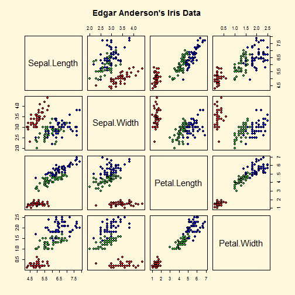

```
##
## > usr <- par("usr")
##
## > rect(usr[1], usr[3], usr[2], usr[4], col="green3")
##
## > contour(x, y, volcano, levels = lev, col="yellow", lty="solid", add=TRUE)
##
## > box()
##
## > title("A Topographic Map of Maunga Whau", font= 4)
##
## > title(xlab = "Meters North", ylab = "Meters West", font= 3)
##
## > mtext("10 Meter Contour Spacing", side=3, line=0.35, outer=FALSE,
## +       at = mean(par("usr")[1:2]), cex=0.7, font=3)
##
## > ## Conditioning plots
## >
## > par(bg="cornsilk")
##
## > coplot(lat ~ long | depth, data = quakes, pch = 21, bg = "green3")
```

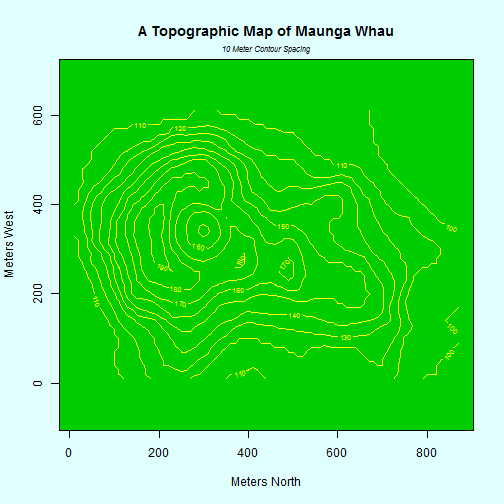

```
##
## > par(opar)
```

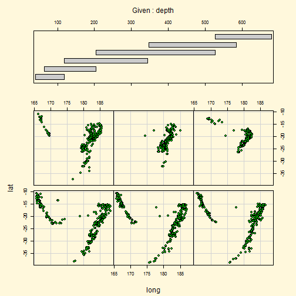

```r
## R functions for base graphics
demo(graphics)
```

```
##
##
##  demo(image)
##  ---- ~~~~~
##
## > require(datasets)
##
## > require(grDevices); require(graphics)
##
## > x <- 10*(1:nrow(volcano)); x.at <- seq(100, 800, by=100)
##
## > y <- 10*(1:ncol(volcano)); y.at <- seq(100, 600, by=100)
##
## >                    # Using Terrain Colors
## >
## > image(x, y, volcano, col=terrain.colors(100),axes=FALSE)
```

```
##
## > contour(x, y, volcano, levels=seq(90, 200, by=5), add=TRUE, col="brown")
##
## > axis(1, at=x.at)
##
## > axis(2, at=y.at)
##
## > box()
##
## > title(main="Maunga Whau Volcano", sub = "col=terrain.colors(100)", font.main=4)
##
## >                    # Using Heat Colors
## >
## > image(x, y, volcano, col=heat.colors(100), axes=FALSE)
```

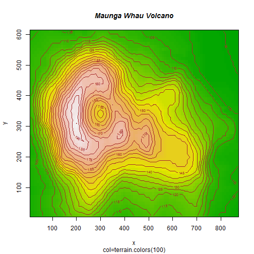

```
##
## > contour(x, y, volcano, levels=seq(90, 200, by=5), add=TRUE, col="brown")
##
## > axis(1, at=x.at)
##
## > axis(2, at=y.at)
##
## > box()
##
## > title(main="Maunga Whau Volcano", sub = "col=heat.colors(100)", font.main=4)
##
## >                    # Using Gray Scale
## >
## > image(x, y, volcano, col=gray(100:200/200), axes=FALSE)
```

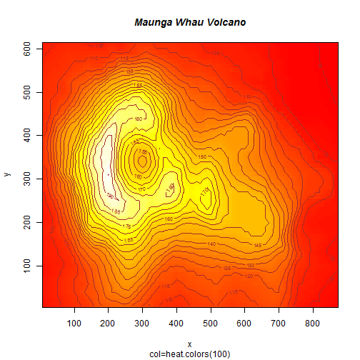

```
##
## > contour(x, y, volcano, levels=seq(90, 200, by=5), add=TRUE, col="black")
##
## > axis(1, at=x.at)
##
## > axis(2, at=y.at)
##
## > box()
##
## > title(main="Maunga Whau Volcano \n col=gray(100:200/200)", font.main=4)
##
## > ## Filled Contours are even nicer sometimes :
## > example(filled.contour)
##
## flld.c> require(grDevices) # for colours
##
## flld.c> filled.contour(volcano, color = terrain.colors, asp = 1)# simple
```

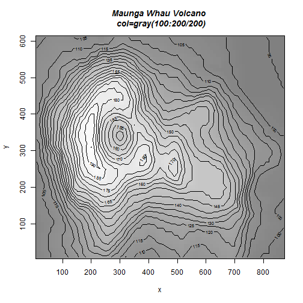

```
##
## flld.c> x <- 10*1:nrow(volcano)
##
## flld.c> y <- 10*1:ncol(volcano)
##
## flld.c> filled.contour(x, y, volcano, color = terrain.colors,
## flld.c+     plot.title = title(main = "The Topography of Maunga Whau",
## flld.c+     xlab = "Meters North", ylab = "Meters West"),
## flld.c+     plot.axes = { axis(1, seq(100, 800, by = 100))
## flld.c+                   axis(2, seq(100, 600, by = 100)) },
## flld.c+     key.title = title(main="Height\n(meters)"),
## flld.c+     key.axes = axis(4, seq(90, 190, by = 10)))# maybe also asp=1
```

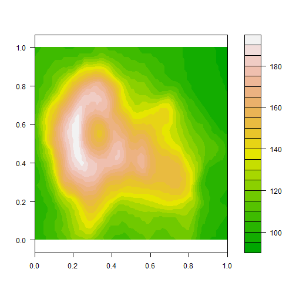

```
##
## flld.c> mtext(paste("filled.contour(.) from", R.version.string),
## flld.c+       side = 1, line = 4, adj = 1, cex = .66)
##
## flld.c> # Annotating a filled contour plot
## flld.c> a <- expand.grid(1:20, 1:20)
##
## flld.c> b <- matrix(a[,1] + a[,2], 20)
##
## flld.c> filled.contour(x = 1:20, y = 1:20, z = b,
## flld.c+                plot.axes={ axis(1); axis(2); points(10,10) })
```

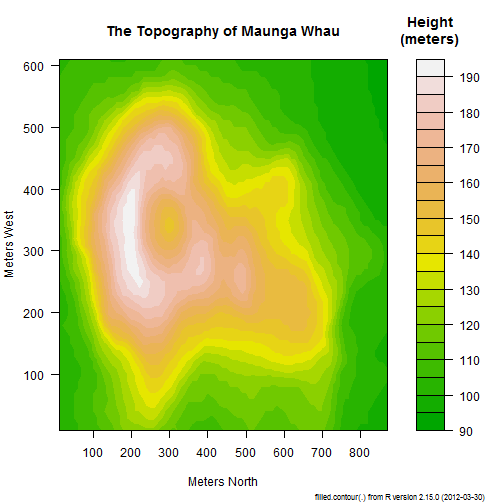

```
##
## flld.c> ## Persian Rug Art:
## flld.c> x <- y <- seq(-4*pi, 4*pi, len = 27)
##
## flld.c> r <- sqrt(outer(x^2, y^2, "+"))
##
## flld.c> filled.contour(cos(r^2)*exp(-r/(2*pi)), axes = FALSE)
```

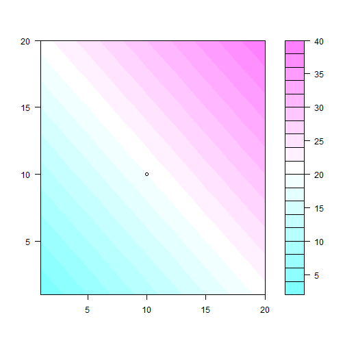

```
##
## flld.c> ## rather, the key *should* be labeled:
## flld.c> filled.contour(cos(r^2)*exp(-r/(2*pi)), frame.plot = FALSE,
## flld.c+                plot.axes = {})
```

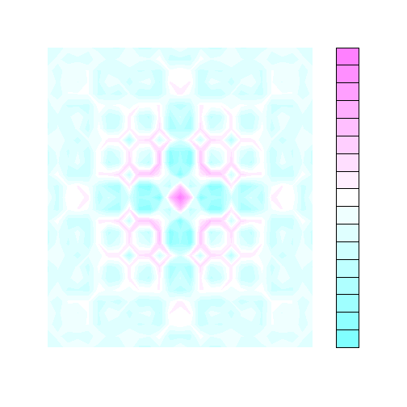

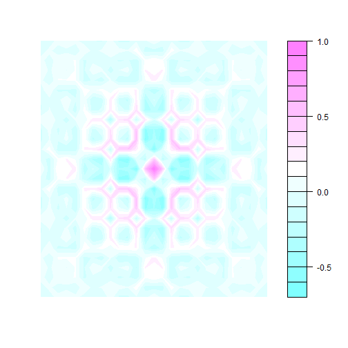

```r
demo(image)
```

```
##
##
##  demo(persp)
##  ---- ~~~~~
##
## > ### Demos for  persp()  plots   -- things not in  example(persp)
## > ### -------------------------
## >
## > require(datasets)
##
## > require(grDevices); require(graphics)
##
## > ## (1) The Obligatory Mathematical surface.
## > ##     Rotated sinc function.
## >
## > x <- seq(-10, 10, length.out = 50)
##
## > y <- x
##
## > rotsinc <- function(x,y)
## + {
## +     sinc <- function(x) { y <- sin(x)/x ; y[is.na(y)] <- 1; y }
## +     10 * sinc( sqrt(x^2+y^2) )
## + }
##
## > sinc.exp <- expression(z == Sinc(sqrt(x^2 + y^2)))
##
## > z <- outer(x, y, rotsinc)
##
## > oldpar <- par(bg = "white")
##
## > persp(x, y, z, theta = 30, phi = 30, expand = 0.5, col = "lightblue")
##
## > title(sub=".")## work around persp+plotmath bug
##
## > title(main = sinc.exp)
##
## > persp(x, y, z, theta = 30, phi = 30, expand = 0.5, col = "lightblue",
## +       ltheta = 120, shade = 0.75, ticktype = "detailed",
## +       xlab = "X", ylab = "Y", zlab = "Z")
```

[output cut: 56 more lines]

```
## > fcol <- fill
##
## > zi <- volcano[ -1,-1] + volcano[ -1,-61] +
## +            volcano[-87,-1] + volcano[-87,-61]  ## / 4
##
## > fcol[-i1,-i2] <-
## +     terrain.colors(20)[cut(zi,
## +                            stats::quantile(zi, seq(0,1, length.out = 21)),
## +                            include.lowest = TRUE)]
##
## > persp(x, y, 2*z, theta = 110, phi = 40, col = fcol, scale = FALSE,
## +       ltheta = -120, shade = 0.4, border = NA, box = FALSE)
##
## > ## reset par():
## > par(oldpar)
```

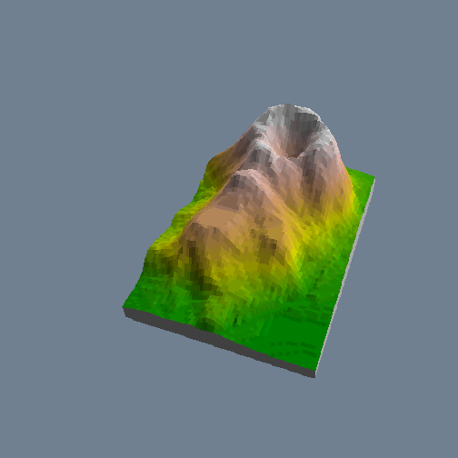

```r
demo(persp)
```

```
##
##
##  demo(plotrix)
##  ---- ~~~~~~~
##
## > # The plotrix demo in roughly alphabetical order
## > # Press <Enter> to advance through the demo,
## > # Ctrl-C (Linux) or Esc (Windows) to exit
## > par(ask=TRUE)
##
## > x <- rnorm(100)
##
## > y <- x + rnorm(100)
##
## > lmfit <- lm(y~x)
##
## > plot(x,y,xlim=c(-3.5,3.5),main="Ablineclip")
```

```
##
## > ablineclip(lmfit,x1=-2,x2=2,lty=2)
##
## > ablineclip(h=0,x1=-2,x2=2,lty=3,col="red")
##
## > ablineclip(v=0,y1=-2.5,y2=1.5,lty=4,col="green")
##
## > testdf<-data.frame(Before=c(10,7,5),During=c(8,6,2),After=c(5,3,4))
##
## > rownames(testdf)<-c("Red","Green","Blue")
##
## > barp(testdf,main="Test addtable2plot",ylab="Value",
## +  names.arg=colnames(testdf),col=2:4)
```

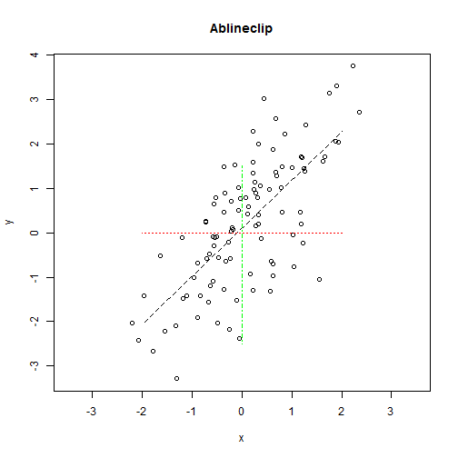

```
##
## > addtable2plot(2,8,testdf,bty="o",display.rownames=TRUE,hlines=TRUE,
## +  title="The table")
##
## > plot(0,xlim=c(1,5),ylim=c(1,5),main="Arctext",xlab="",ylab="",
## +  type="n")
```

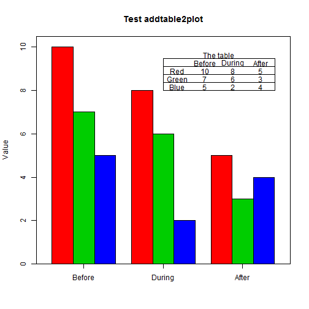

```
##
## > arctext("bendy like spaghetti",center=c(3,3),col="blue")
##
## > arctext("bendy like spaghetti",center=c(3,3),radius=1.5,start=pi,cex=2)
##
## > arctext("bendy like spaghetti",center=c(3,3),radius=0.5,
## +  start=pi/2,stretch=1.2)
##
## > plot(3:10,main="Axis break test")
```

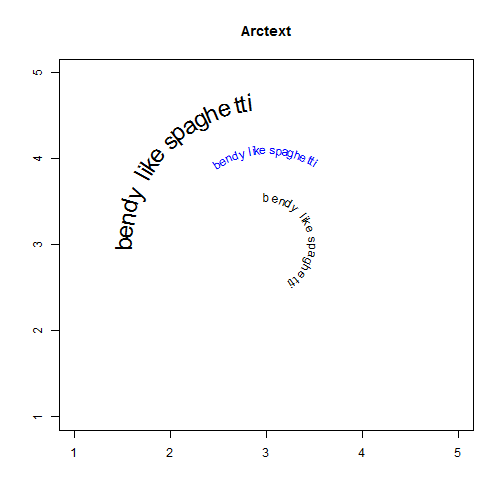

```
##
## > # put a break at the default axis and position
## > axis.break()
##
## > axis.break(2,2.9,style="zigzag")
##
## > twogrp<-c(rnorm(10)+4,rnorm(10)+20)
##
## > gap.plot(twogrp,gap=c(8,16),xlab="Index",ylab="Group values",
## +  main="Two separated groups with gap axis break",
## +  col=c(rep(2,10),rep(3,10)),ytics=c(3,5,18,20))
```

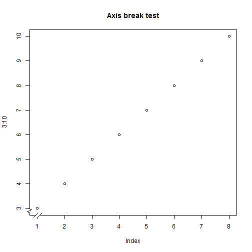

```
##
## > legend(12,6,c("Low group","High group"),pch=1,col=2:3)
##
## > plot(1:10*0.001,1:10*100,axes=FALSE,xlab="",ylab="",main="Axis multipliers")
```

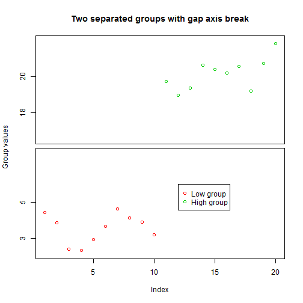

```
##
## > box()
##
## > axis.mult(1,mult=0.001)
##
## > axis.mult(2,mult=100)
##
## > par(mar=c(5,5,4,2))
##
## > test.df<-data.frame(Age=rnorm(100,25,10),
## +  Sex=sample(c("M","F"),100,TRUE),
## +  Marital=sample(c("M","X","S","W"),100,TRUE),
## +  Employ=sample(c("FT","PT","NO"),100,TRUE))
##
## > test.col<-list(Overall="green",Employ=c("purple","orange","brown"),
## +  Marital=c("#1affd8","#caeecc","#f7b3cc","#94ebff"),Sex=c(2,4))
##
## > barNest(formula=Age~Employ+Marital+Sex,data=test.df,main="barNest",
## +  col=test.col,showall=TRUE)
```

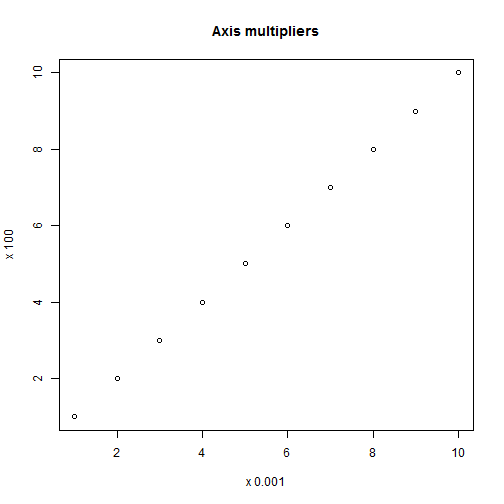

```
##
## > happyday<-data.frame(Monday=c(2.3,3.4),Tuesday=c(2.8,3.3),Wednesday=c(3.2,3.1),
## + Thursday=c(3.6,2.8),Friday=c(4.2,2.6),Saturday=c(4.5,2.9),Sunday=c(4.1,2.8))
##
## > happylabels<-c("Utterly dashed","Rather mopey","Indifferent","Somewhat elated",
## +  "Euphoric")
##
## > barp(happyday,names.arg=names(happyday),legend.lab=c("Slaves","Unemployed"),
## +  legend.pos=list(x=2,y=4.5),col=c("#ee7700","#3333ff"),
## +  main="Test of barp, staxlab and color.legend",
## +  xlab="Day of week",ylab="Happiness rating",ylim=c(1,5),staxx=TRUE,staxy=TRUE,
## +  height.at=1:5,height.lab=happylabels,cex.axis=0.9,cylindrical=TRUE,
## +  shadow=TRUE)
```

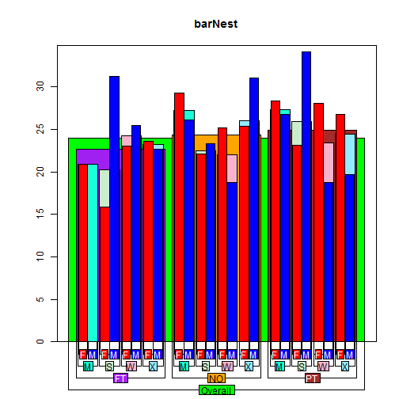

```
##
## > par(mar=c(5,4,4,2))
##
## > h1<-table(cut(rnorm(100,4),breaks=seq(0,8,by=2)))
##
## > h2<-table(cut(rnorm(100,4),breaks=seq(0,8,by=2)))
##
## > h3<-table(cut(rnorm(100,4),breaks=seq(0,8,by=2)))
##
## > hmat<-matrix(c(h1,h2,h3),nrow=3,byrow=TRUE)
##
## > barp(hmat,names.arg=names(h1),width=0.45,col=2:4,
## +  main="Multiple histogram using barp",xlab="Bins",ylab="Frequency")
```

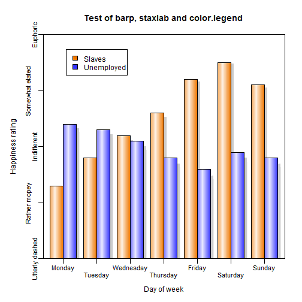

```
##
## > legend(3.8,50,c("h1","h2","h3"),fill=2:4)
##
## > x<-rnorm(10)
##
## > y<-rnorm(10)
##
## > plot(x,y,type="p",main="Boxed.labels")
```

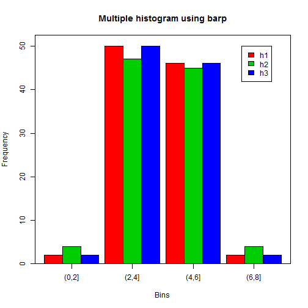

```
##
## > nums<-c("one","two","three","four","five","six","seven","eight","nine","ten")
##
## > boxed.labels(x,y-0.1,nums)
##
## > test.df<-data.frame(a=rnorm(80)+4,b=rnorm(80)+4,c=rep(LETTERS[1:4],each=20),
## +  d=rep(rep(letters[1:4],each=4),5))
##
## > bp<-brkdn.plot("a","c","d",test.df,main="Test of brkdn.plot",
## +  mct="median",md="mad",xlab="Temperature range", ylab="Cognition",
## +  xaxlab=c("10-15","16-20","21-25","25-30"),pch=1:4,lty=1:4,col=1:4,ylim=c(0,6))
```

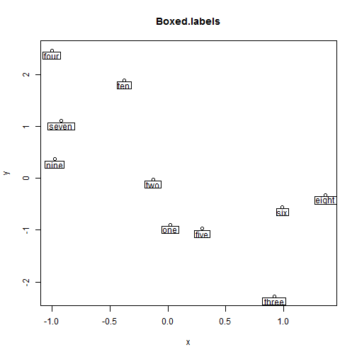

```
##
## > legend(1,2.5,legend=c("Sydney","Gosford","Karuah","Brisbane"),pch=1:4,
## +  col=1:4,lty=1:4,xjust=0.5,yjust=0.5)
##
## > educattn<-matrix(c(90.4,90.3,75.7,78.9,66,71.8,70.5,70.4,68.4,67.9,
## +  67.2,76.1,68.1,74.7,68.5,72.4,64.3,71.2,73.1,77.8),ncol=2,byrow=TRUE)
##
## > rownames(educattn)<-c("Anchorage AK","Boston MA","Chicago IL",
## +  "Houston TX","Los Angeles CA","Louisville KY","New Orleans LA",
## +  "New York NY","Philadelphia PA","Washington DC")
##
## > colnames(educattn)<-c(1990,2000)
##
## > bumpchart(educattn,rank=FALSE,
## +  main="Percentage high school completion by over 25s",col=rainbow(10))
```

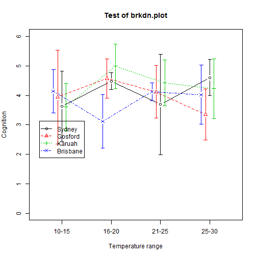

```
##
## > # margins have been reset, so use
## > par(xpd=TRUE)
##
## > boxed.labels(1.5,seq(65,90,by=5),seq(65,90,by=5))
##
## > par(xpd=FALSE)
##
## > testcp<-list("",40)
##
## > for(i in 1:40) testcp[[i]]<-rnorm(sample(1:8,1)*50)
##
## > segs<-get.segs(testcp)
##
## > centipede.plot(segs,main="Centipede plot",vgrid=0)
```

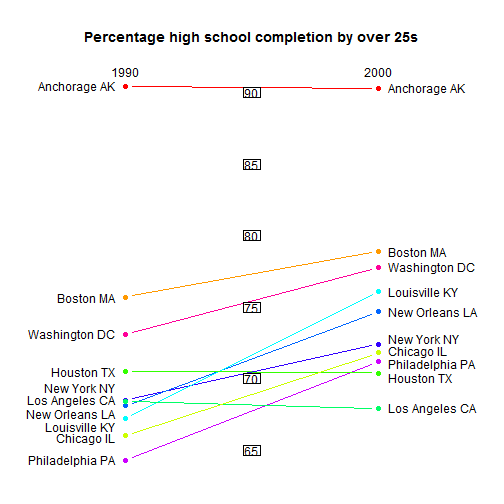

```
##
## > xy.mat<-cbind(sample(1:10,200,TRUE),sample(1:10,200,TRUE))
##
## > clusteredpoints<-
## +  cluster.overplot(xy.mat,col=rep(c("red","green"),each=100))
```

[43 more figures not shown]

```
##
## > readline("End of demo, press <Enter>")
## End of demo, press <Enter>
## [1] ""
##
## > par(ask=FALSE)
##
## > dev.off()
## null device
##           1
```

```r
require(plotrix)
demo(plotrix)
```

```r
require(lattice)
demo(lattice)
```

```
##
##
##  demo(lattice)
##  ---- ~~~~~~~
##
## > require(grid)
```

```
##
## > old.prompt <- devAskNewPage(TRUE)
##
## > ## store current settings, to be restored later
## > old.settings <- trellis.par.get()
##
## > ## changing settings to new 'theme'
## > trellis.par.set(theme = col.whitebg())
##
## > ## simulated example, histogram and kernel density estimate superposed
## > x <- rnorm(500)
##
## > densityplot(~x)
```

```
##
## > histogram(x, type = "density",
## +           panel = function(x, ...) {
## +               panel.histogram(x, ...)
## +               panel.densityplot(x, col = "brown", plot.points = FALSE)
## +           })
```

```
##
## > ## Using a custom panel function to superpose a fitted normal density
## > ## on a Kernel Density Estimate
## >
## > densityplot( ~ height | voice.part, data = singer, layout = c(2, 4),
## +             xlab = "Height (inches)",
## +             ylab = "Kernel Density\n with Normal Fit",
## +             main = list("Estimated Density", cex = 1.4, col = "DarkOliveGreen"),
## +             panel = function(x, ...) {
## +                 panel.densityplot(x, ...)
## +                 panel.mathdensity(dmath = dnorm,
## +                                   args = list(mean=mean(x),sd=sd(x)))
## +             } )
```

```
##
## > ## user defined panel functions and fonts
## >
## > states <- data.frame(state.x77,
## +                      state.name = dimnames(state.x77)[[1]],
## +                      state.region = factor(state.region))
##
## > xyplot(Murder ~ Population | state.region, data = states,
## +        groups = state.name,
## +        panel = function(x, y, subscripts, groups)
## +        ltext(x = x, y = y, labels = groups[subscripts],
## +              cex=.9, fontfamily = "HersheySans", fontface = "italic"),
## +        par.strip.text = list(cex = 1.3, font = 4, col = "brown"),
## +        xlab = list("Estimated Population, July 1, 1975", font = 2),
## +        ylab = list("Murder Rate (per 100,000 population), 1976", font = 2),
## +        main = list("Murder Rates in US states", col = "brown", font = 4))
```

```
##
## > ##graphical parameters for xlab etc can also be changed permanently
## > trellis.par.set(list(par.xlab.text = list(font = 2),
## +                      par.ylab.text = list(font = 2),
## +                      par.main.text = list(font = 4, col = "brown")))
##
## > ## Same with some multiple line text
## > levels(states$state.region) <-
## +     c("Northeast", "South", "North\n Central",  "West")
##
## > xyplot(Murder  ~ Population | state.region, data = states,
## +        groups = as.character(state.name),
## +        panel = function(x, y, subscripts, groups)
## +        ltext(x = x, y = y, labels = groups[subscripts], srt = -50, col = "blue",
## +              cex=.9, fontfamily = "HersheySans"),
## +        par.strip.text = list(cex = 1.3, font = 4, col = "brown", lines = 2),
## +        xlab = "Estimated Population\nJuly 1, 1975",
## +        ylab = "Murder Rate \n(per 100,000 population)\n 1976",
## +        main = "Murder Rates in US states")
```

```
##
## > ##setting these back to their defaults
## > trellis.par.set(list(par.xlab.text = list(font = 1),
## +                      par.ylab.text = list(font = 1),
## +                      par.main.text = list(font = 2, col = "black")))
##
## > ##levelplot
## >
## > levelplot(volcano, colorkey = list(space = "top"),
## +           sub = "Maunga Whau volcano", aspect = "iso")
```

```
##
## > ## wireframe
## > wireframe(volcano, shade = TRUE,
## +           aspect = c(61/87, 0.4),
## +           screen = list(z = -120, x = -45),
## +           light.source = c(0,0,10), distance = .2,
## +           shade.colors.palette = function(irr, ref, height, w = .5)
## +           grey(w * irr + (1 - w) * (1 - (1-ref)^.4)))
```

```
##
## > ## 3-D surface parametrized on a 2-D grid
## >
## > n <- 50
##
## > tx <- matrix(seq(-pi, pi, length.out = 2*n), 2*n, n)
##
## > ty <- matrix(seq(-pi, pi, length.out = n) / 2, 2*n, n, byrow = T)
##
## > xx <- cos(tx) * cos(ty)
##
## > yy <- sin(tx) * cos(ty)
##
## > zz <- sin(ty)
##
## > zzz <- zz
##
## > zzz[,1:12 * 4] <- NA
##
## > wireframe(zzz ~ xx * yy, shade = TRUE, light.source = c(3,3,3))
```

```
##
## > ## Example with panel.superpose.
## >
## > xyplot(Petal.Length~Petal.Width, data = iris, groups=Species,
## +        panel = panel.superpose,
## +        type = c("p", "smooth"), span=.75,
## +        col.line = trellis.par.get("strip.background")$col,
## +        col.symbol = trellis.par.get("strip.shingle")$col,
## +        key = list(title = "Iris Data", x = .15, y=.85, corner = c(0,1),
## +            border = TRUE,
## +            points = list(col=trellis.par.get("strip.shingle")$col[1:3],
## +            pch = trellis.par.get("superpose.symbol")$pch[1:3],
## +            cex = trellis.par.get("superpose.symbol")$cex[1:3]
## +            ),
## +            text = list(levels(iris$Species))))
```

```
##
## > ## non-trivial strip function
## >
## > barchart(variety ~ yield | year * site, barley, origin = 0,
## +          layout = c(4, 3),
## +          between = list(x = c(0, 0.5, 0)),
## +          ## par.settings = list(clip = list(strip = "on")),
## +          strip =
## +          function(which.given,
## +                   which.panel,
## +                   factor.levels,
## +                   bg = trellis.par.get("strip.background")$col[which.given],
## +                   ...) {
## +              axis.line <- trellis.par.get("axis.line")
## +              pushViewport(viewport(clip = trellis.par.get("clip")$strip,
## +                                    name = trellis.vpname("strip")))
## +              if (which.given == 1)
## +              {
## +                  grid.rect(x = .26, just = "right",
## +                            name = trellis.grobname("fill", type="strip"),
## +                            gp = gpar(fill = bg, col = "transparent"))
## +                  ltext(factor.levels[which.panel[which.given]],
## +                        x = .24, y = .5, adj = 1,
## +                        name.type = "strip")
## +              }
## +              if (which.given == 2)
## +              {
## +                  grid.rect(x = .26, just = "left",
## +                            name = trellis.grobname("fill", type="strip"),
## +                            gp = gpar(fill = bg, col = "transparent"))
## +                  ltext(factor.levels[which.panel[which.given]],
## +                        x = .28, y = .5, adj = 0,
## +                        name.type = "strip")
## +              }
## +              upViewport()
## +              grid.rect(name = trellis.grobname("border", type="strip"),
## +                        gp =
## +                        gpar(col = axis.line$col,
## +                             lty = axis.line$lty,
## +                             lwd = axis.line$lwd,
## +                             alpha = axis.line$alpha,
## +                             fill = "transparent"))
## +          }, par.strip.text = list(lines = 0.4))
```

```
##
## > trellis.par.set(theme = old.settings, strict = 2)
##
## > devAskNewPage(old.prompt)
```

```r
require(rgl)
demo(rgl)
```

```
##
##
##  demo(rgl)
##  ---- ~~~
##
## > # all rgl demos
## > demo(hist3d)
##
##
##  demo(hist3d)
##  ---- ~~~~~~
##
## > ##########
## > ### 3D HIST EXAMPLE:
## > ##########
## >
## > ################################################################################
## >
## > ##### Required functions 'binplot' and 'hist3d':
## >
## > binplot.3d<-function(x,y,z,alpha=1,topcol="#ff0000",sidecol="#aaaaaa")
## + {
## +   save <- par3d(skipRedraw=TRUE)
## +   on.exit(par3d(save))
## +
## +   x1<-c(rep(c(x[1],x[2],x[2],x[1]),3),rep(x[1],4),rep(x[2],4))
## +   z1<-c(rep(0,4),rep(c(0,0,z,z),4))
## +   y1<-c(y[1],y[1],y[2],y[2],rep(y[1],4),rep(y[2],4),rep(c(y[1],y[2],y[2],y[1]),2))
## +   x2<-c(rep(c(x[1],x[1],x[2],x[2]),2),rep(c(x[1],x[2],rep(x[1],3),rep(x[2],3)),2))
## +   z2<-c(rep(c(0,z),4),rep(0,8),rep(z,8) )
## +   y2<-c(rep(y[1],4),rep(y[2],4),rep(c(rep(y[1],3),rep(y[2],3),y[1],y[2]),2) )
## +   rgl.quads(x1,z1,y1,col=rep(sidecol,each=4),alpha=alpha)
## +   rgl.quads(c(x[1],x[2],x[2],x[1]),rep(z,4),c(y[1],y[1],y[2],y[2]),
## +               col=rep(topcol,each=4),alpha=1)
## +   rgl.lines(x2,z2,y2,col="#000000")
## + }
##
## > hist3d<-function(x,y=NULL,nclass="auto",alpha=1,col="#ff0000",scale=10)
## +   {
## +   save <- par3d(skipRedraw=TRUE)
```

[output cut: 490 more lines]

```
## +   # setup env:
## +   bg3d(color="#887777")
## +   light3d()
## +
## +   # Draws the simulated data as spheres on the baseline
## +   spheres3d(x,y,rep(0,n),radius=0.1,color="#CCCCFF")
## +
## +   # Draws non-parametric density
## +   surface3d(xgrid,ygrid,den.z*zscale,color="#FF2222",alpha=0.5)
## +
## +   # Draws parametric density
## +   surface3d(xgrid,ygrid,bi.z*zscale,color="#CCCCFF",front="lines")
## + }
##
## > rgl.demo.bivar()
```

To see more at the [R Graph Gallery](http://addictedtor.free.fr/graphiques)

## Organization

- Graphics Systems  
  There are two big graphics systems in R, `traditional graphics` and `grid`.
- Graphics Devices (package)  
  Default (`grDevices`), Cairo/GTK (`cairoDevice`), SVG (`RSvgDevice`), Java (`JavaGD`), OpenGL (`rgl`), Gtk (`RGtk2`)
- Graphics Packages
  - `graphics` (traditional graphics system)
  - `lattice`, `ggplot2` (grid system)
  - …
- I'll omit all details here, and turn back if necessary later. For more information, see http://cran.r-project.org/web/views/Graphics.html

# Traditional Graphics

We'll cover most of the functions in `graphics` package in this section.

To begin with, let's have a look at the most usually used function `plot()`.

## `plot()` function

Recall that `plot()` is a [generic function](http://dreamhunter.me/bbpress/Rstudy/Rclass3.html), so it can accept objects from a variety of [classes](http://dreamhunter.me/bbpress/Rstudy/attributes.html). But many methods will accept the following arguments:

- `x`: coordinates OR function OR R object with a plot method can be provided.
- `y`: y coordinates OR optional if x is an appropriate structure.
- `type`: what type of plot should be drawn. Possible types are `"p", "l", "b", "c", "o", "h", "s", "S", "n"`
- main: an overall title for the plot
- sub: a sub title for the plot
- xlab: a title for the x axis
- ylab: YOU KNOW
- asp: the y/x aspect ratio

Also we can check the arguments of the `plot.default()` function, we can note it has more arguments, I won't explain more arguments here, but notice the defination of `x` and `y` here, they are different from the `plot()` function's. I hope you can understand the underlying mechanism, if not please read [S3 methods](http://dreamhunter.me/bbpress/Rstudy/Rclass3.html) carefully.  
Let's study these arguments through some examples.

### `type`

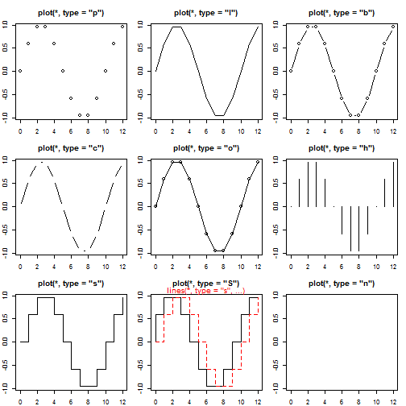

```r
## The `types` arguments
x <- 0:12
y <- sin(pi/5 * x)
op <- par(mfrow = c(3, 3), mar = 0.1 + c(2, 2, 3, 1))
for (tp in c("p", "l", "b", "c", "o", "h", "s", "S", "n")) {
    plot(y ~ x, type = tp, main = paste("plot(*, type = \"", tp, "\")", sep = ""))
    if (tp == "S") {
        lines(x, y, type = "s", col = "red", lty = 2)
        mtext("lines(*, type = \"s\", ...)", col = "red", cex = 0.8)
    }
}
```

```r
par(op)
```

### `pch`

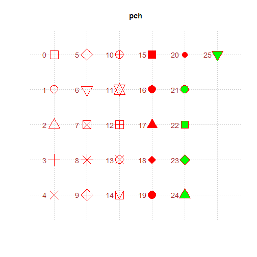

```r
ipch <- 0:25
k <- 5
dd <- c(-1, 1)/2
rx <- dd + range(ix <- ipch%/%k)
ry <- dd + range(iy <- k - ipch%%k)
plot(rx, ry, type = "n", axes = FALSE, xlab = "", ylab = "", main = "pch")
abline(v = ix, h = iy, col = "lightgray", lty = "dotted")
for (i in 1:26) {
    pc <- ipch[i]
    ## 'col' symbols with a 'bg'-colored interior (where available) :
    points(ix[i], iy[i], pch = pc, col = "red", bg = "green", cex = 3)
    text(ix[i] - 0.3, iy[i], pc, col = "brown", cex = 1.2)
}
```

## *High-level* Functions

Generally speaking, a *High-level* plotting function is a function that can be used to produce a complete plot by itself. Let's have a look at some of the most usually used high-level functions through the following examples:

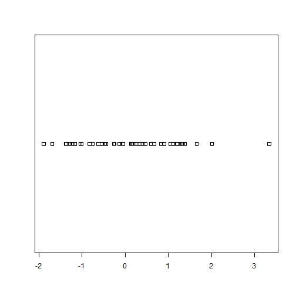

```r
## stripchart
x <- rnorm(50)
xr <- round(x, 1)
stripchart(x)
```

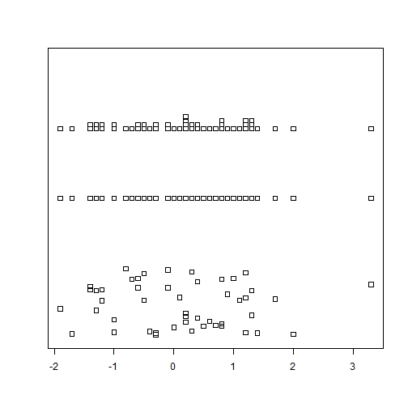

```r
stripchart(xr)
stripchart(xr, method = "stack", add = TRUE, at = 1.2)
stripchart(xr, method = "jitter", add = TRUE, at = 0.7)
```

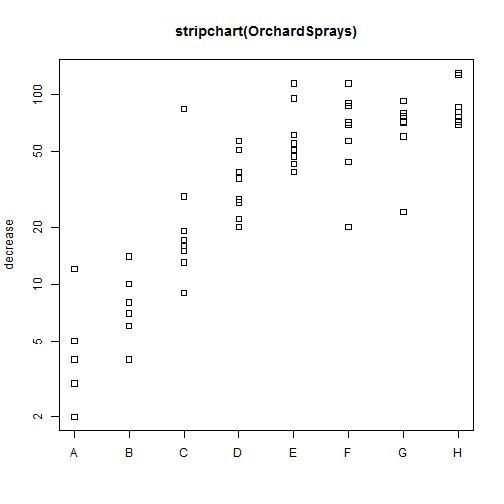

```r
stripchart(decrease ~ treatment, main = "stripchart(OrchardSprays)",
    vertical = TRUE, log = "y", data = OrchardSprays)
```

```r
## stem
stem(islands)
```

```
##
##   The decimal point is 3 digit(s) to the right of the |
##
##    0 | 00000000000000000000000000000111111222338
##    2 | 07
##    4 | 5
##    6 | 8
##    8 | 4
##   10 | 5
##   12 |
##   14 |
##   16 | 0
##
```

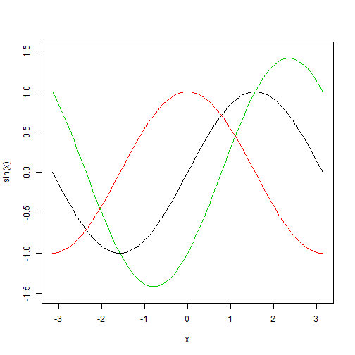

```r
# stem(islands, scale = 2)

## curve
curve(sin, -pi, pi, ylim = c(-1.5, 1.5))
curve(cos, -pi, pi, add = TRUE, col = 2)
curve(sin(x) - cos(x), -pi, pi, add = TRUE, col = 3)
```

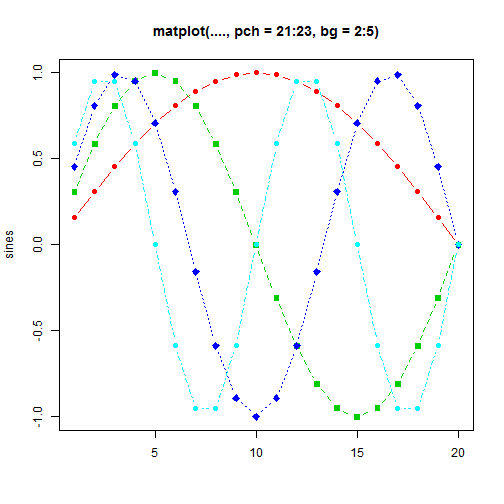

```r
## matplot
sines <- outer(1:20, 1:4, function(x, y) sin(x/20 * pi * y))
matplot(sines, type = "b", pch = 21:23, col = 2:5, bg = 2:5, main = "matplot(...., pch = 21:23, bg = 2:5)")
```

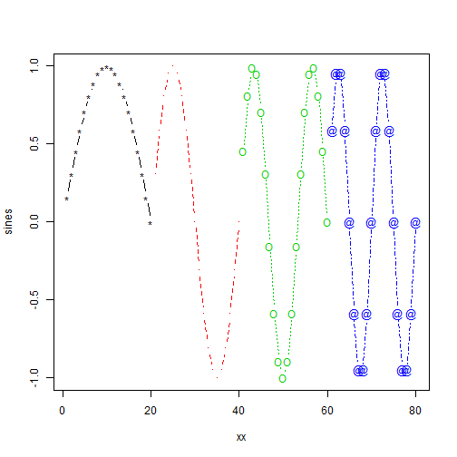

```r
xx <- outer(1:20, 0:3, function(x, y) x + 20 * y)
matplot(xx, sines, type = "b", pch = c("*", ".", "O", "@"))
```

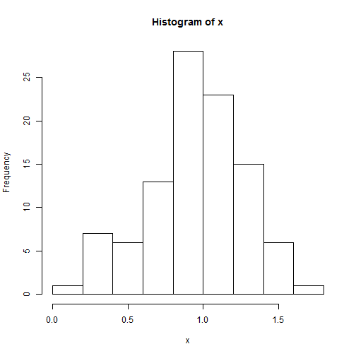

```r
## hist
x <- rnorm(100, 1, 0.3)
y <- hist(x)
```

```r
str(y)
```

```
## List of 7
##  $ breaks     : num [1:10] 0 0.2 0.4 0.6 0.8 1 1.2 1.4 1.6 1.8
##  $ counts     : int [1:9] 1 7 6 13 28 23 15 6 1
##  $ intensities: num [1:9] 0.05 0.35 0.3 0.65 1.4 1.15 0.75 0.3 0.05
##  $ density    : num [1:9] 0.05 0.35 0.3 0.65 1.4 1.15 0.75 0.3 0.05
##  $ mids       : num [1:9] 0.1 0.3 0.5 0.7 0.9 1.1 1.3 1.5 1.7
##  $ xname      : chr "x"
##  $ equidist   : logi TRUE
##  - attr(*, "class")= chr "histogram"
```

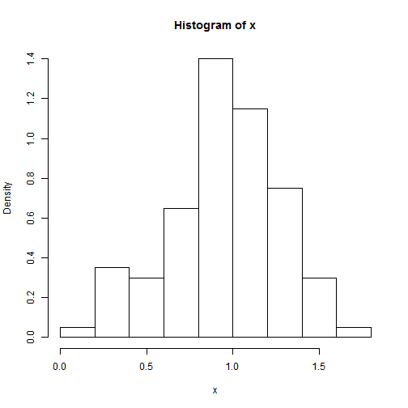

```r
hist(x, freq = FALSE)  # OR probability = TRUE
```

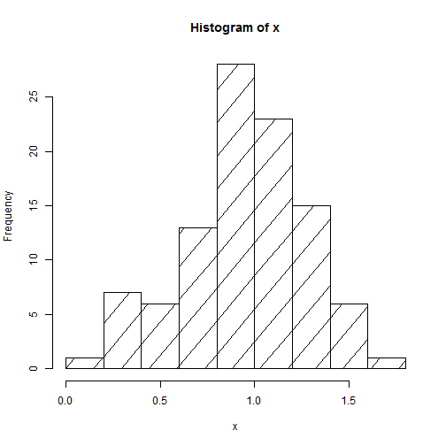

```r
hist(x, density = 3, angle = 50)
```

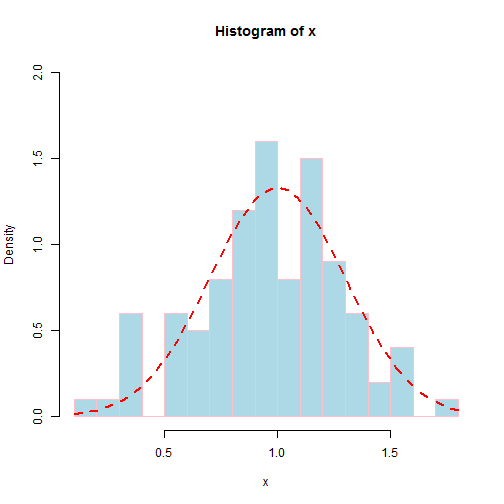

```r
hist(x, prob = TRUE, breaks = 12, col = "lightblue", border = "pink",
    ylim = c(0, 2))
curve(dnorm(x, 1, 0.3), col = 2, lty = 2, lwd = 2, add = TRUE)
```

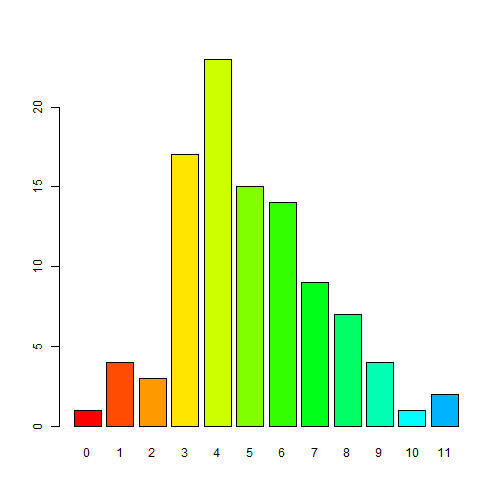

```r
## barplot
tN <- table(Ni <- stats::rpois(100, lambda = 5))
r <- barplot(tN, col = rainbow(20))
```

```r
VADeaths
```

```
##       Rural Male Rural Female Urban Male Urban Female
## 50-54       11.7          8.7       15.4          8.4
## 55-59       18.1         11.7       24.3         13.6
## 60-64       26.9         20.3       37.0         19.3
## 65-69       41.0         30.9       54.6         35.1
## 70-74       66.0         54.3       71.1         50.0
```

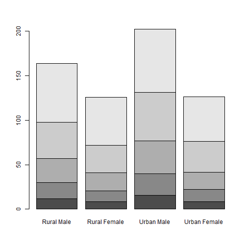

```r
mp <- barplot(VADeaths)  # default
```

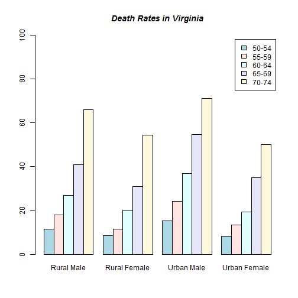

```r
barplot(VADeaths, beside = TRUE, col = c("lightblue", "mistyrose",
    "lightcyan", "lavender", "cornsilk"), legend = rownames(VADeaths), ylim = c(0,
    100))
title(main = "Death Rates in Virginia", font.main = 4)
```

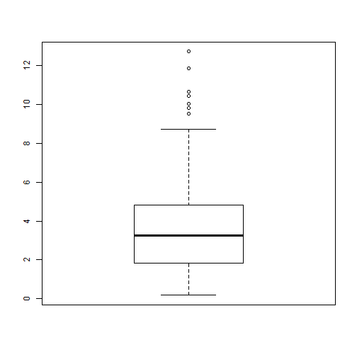

```r
## boxplot boxplot on a vector
boxplot(rchisq(100, df = 4))
```

```r
head(InsectSprays, 5)
```

```
##   count spray
## 1    10     A
## 2     7     A
## 3    20     A
## 4    14     A
## 5    14     A
```

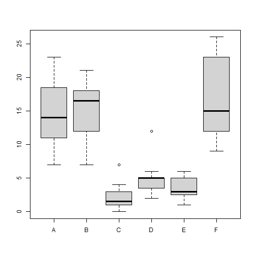

```r
# boxplot on a formula
boxplot(count ~ spray, data = InsectSprays, col = "lightgray")
```

```r
head(OrchardSprays)
```

```
##   decrease rowpos colpos treatment
## 1       57      1      1         D
## 2       95      2      1         E
## 3        8      3      1         B
## 4       69      4      1         H
## 5       92      5      1         G
## 6       90      6      1         F
```

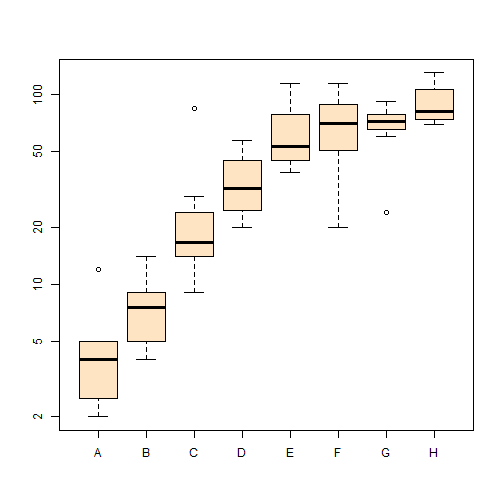

```r
boxplot(decrease ~ treatment, data = OrchardSprays, log = "y", col = "bisque")
```

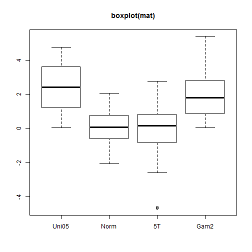

```r
# boxplot on a matrix
mat <- cbind(Uni05 = (1:100)/21, Norm = rnorm(100), `5T` = rt(100,
    df = 5), Gam2 = rgamma(100, shape = 2))
boxplot(mat, main = "boxplot(mat)")
```

## *Low-level* Functions

It is very often the case that a high-level plotting function does not produce exactly the final result that is desired. In this case, we should use low-level functions to control the fine details of a plot. Also let's have a look at some of the low-level functions through examples:

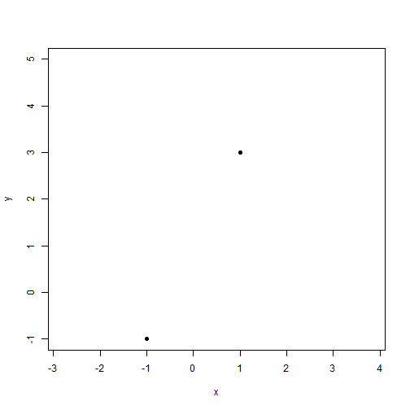

```r
## points
plot(c(-2, 3), c(-1, 5), type = "n", xlab = "x", ylab = "y", asp = 1)
points(c(-1, 1), c(-1, 3), pch = 19)
```

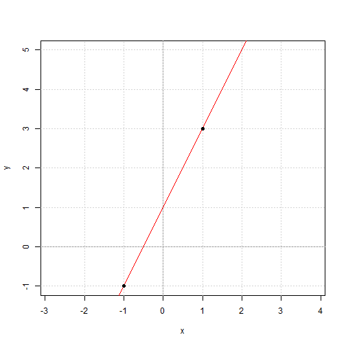

```r
## abline
plot(c(-2, 3), c(-1, 5), type = "n", xlab = "x", ylab = "y", asp = 1)
abline(h = 0, v = 0, col = "gray60")
abline(h = -1:5, v = -2:3, col = "lightgray", lty = 3)
abline(a = 1, b = 2, col = 2)
points(c(-1, 1), c(-1, 3), pch = 19)
```

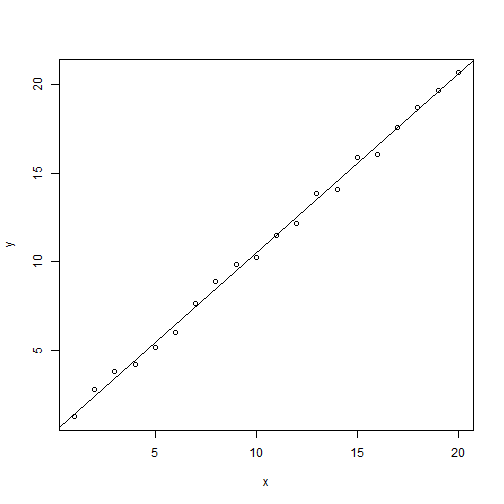

```r
# Simple Regression Lines
x <- 1:20
y <- x + runif(20)
xy.lm <- lm(y ~ x)
plot(x, y)
abline(xy.lm)
```

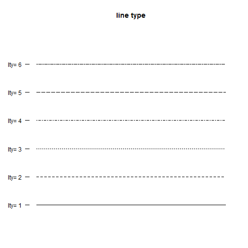

```r
## lines
plot(c(0, 7), c(1, 7), type = "n", ylab = "", xlab = "", axes = FALSE,
    main = "line type")
for (i in 1:6) {
    lines(c(0, 7), c(i, i), lty = i)
    axis(2, at = i, labels = paste("lty=", i), las = 1)
}
```